# Prompt Evaluation & Analysis Report

## 1. Evaluation Dimensions

| Dimension | Description |
| --- | --- |
| **Completeness** | Whether the answer fully addresses the question with sufficient scope and depth. |
| **Relevance** | How well the answer aligns with the prompt intent and phrasing. |
| **Authority** | The credibility of cited sources (e.g., .gov, academic journals). |
| **Recency** | How recent and up-to-date the cited information is. |
| **Factual Accuracy** | Whether the response includes accurate and verifiable facts. |
| **Information Depth** | The level of detail, mechanism, reasoning, or data involved in the answer. |

To evaluate RAG outputs more precisely, we used a six-dimension framework: completeness, relevance, authority, recency, factual accuracy, and information depth. This structure enabled more targeted and nuanced assessments beyond a single overall score, helping reveal not just what was said, but how well-supported and informative each response was.

## 2. Scoring Process and Summary Table

| Prompt_ID | Topic | Prompt_Type | Prompt_Text | Completeness | Relevance | Authority | Recency | Factual_Accuracy | Information_Depth | Average_Score | Notes |
| --- | --- | --- | --- | --- | --- | --- | --- | --- | --- | --- | --- |
| FS-01 | Food Safety | Basic – Simple | What are the most common food safety mistakes in home kitchens? | 4.0 | 5 | 3.0 | 4.0 | 4.0 | 4 | 4.00 | Content is relevant and well structured; however, sources lack government or peer-reviewed authority. Includes practical tips and structured summary but omits high-risk group considerations. |
| FS-02 | Food Safety | Basic – Specific | What are the top 5 most dangerous food safety mistakes people make when cooking at home, and how can these be avoided? | 5.0 | 5 | 3.0 | 4.0 | 4.0 | 4 | 4.17 | Highly structured and complete answer, but sources lack academic or government research. No severity ranking or targeted guidance for at-risk groups. |
| FS-03 | Food Safety | Basic – Background | What are the top 5 most dangerous food safety mistakes people make when cooking at home, and how can these be avoided? | 5.0 | 5 | 3.0 | 4.0 | 4.0 | 4 | 4.17 | Well organized and detailed answer; sources are secondary and lack scientific backing. Explanation of risks present but not data-supported. |
| FS-04 | Food Safety | Context – Personal | As someone who frequently cooks for young children and elderly family members, what are the most important food safety practices I should follow to prevent foodborne illness in these vulnerable groups… | 4.5 | 5 | 5.0 | 4.5 | 5.0 | 4 | 4.67 | Authoritative and tailored to context, with up-to-date government and academic sources. However, some principles lack elaboration. |
| FS-05 | Food Safety | Context – Technical | From a microbiological perspective, what are the most dangerous food handling errors in domestic kitchens that lead to bacterial contamination, and at what temperatures/conditions do these bacteria mu… | 5.0 | 5 | 3.5 | 4.0 | 4.5 | 5 | 4.50 | Rich microbiological detail and practical metrics; missing academic citations and lacks depth on other microbial conditions like humidity/pH. |

*Note: The table above shows the first 5 rows. Full evaluation scores are included in the CSV file.*

Each prompt output was scored across the six dimensions. To ensure fairness, we compared prompts within the same topic and used LLM tools to help convert qualitative judgments into consistent numerical scores. Human oversight was still applied for edge cases such as unclear sources. The resulting scores were aggregated by prompt type, and the summary table below shows the average for each dimension. This forms the basis for deeper analysis.

## 3. Prompt Type vs Score Analysis

To analyze how different prompt types performed, we calculated average scores across all six evaluation dimensions and visualized the results through a combination of summary table, heatmap, and bar chart. These tools provided both detailed and big-picture insights into performance trends.

### 3.1 Summary Table

The summary table below displays the average score for each evaluation dimension by prompt type. We grouped prompt outputs by type and calculated the mean for each dimension, including a final average across all dimensions. This table served as the foundation for further visual analysis.

| Prompt_Type | Completeness | Relevance | Authority | Recency | Factual_Accuracy | Information_Depth | Average_Score |
| --- | --- | --- | --- | --- | --- | --- | --- |
| Basic – Background | 5.00 | 5 | 3.83 | 4.67 | 4.33 | 4.67 | 4.59 |
| Basic – Simple | 4.67 | 5 | 4.33 | 4.33 | 4.67 | 4.00 | 4.50 |
| Basic – Specific | 5.00 | 5 | 3.00 | 4.33 | 4.00 | 4.00 | 4.22 |
| Comparative – Applications | 5.00 | 5 | 4.50 | 5.00 | 4.50 | 4.50 | 4.75 |
| Comparative – Clinical Approaches | 5.00 | 5 | 5.00 | 5.00 | 5.00 | 5.00 | 5.00 |
| Comparative – Cultural | 5.00 | 5 | 5.00 | 4.00 | 5.00 | 5.00 | 4.83 |
| Comparative – Future Developments | 5.00 | 5 | 4.00 | 5.00 | 4.50 | 5.00 | 4.75 |
| Comparative – Geographic | 5.00 | 5 | 3.00 | 4.00 | 4.00 | 4.50 | 4.25 |
| Comparative – Practice Gap | 5.00 | 5 | 5.00 | 5.00 | 4.50 | 4.50 | 4.83 |
| Context – Personal | 4.83 | 5 | 4.67 | 4.67 | 4.83 | 4.33 | 4.72 |
| Context – Technical | 5.00 | 5 | 4.33 | 4.67 | 4.67 | 5.00 | 4.78 |

### 3.2 Heatmap of Evaluation Dimensions

The heatmap provides a visual representation of how each prompt type performed across all six evaluation dimensions. Color intensity corresponds to the score magnitude, making it easy to compare strengths and weaknesses at a glance. This view helps identify prompt types that perform consistently well across dimensions and those that struggle in areas such as authority or depth.

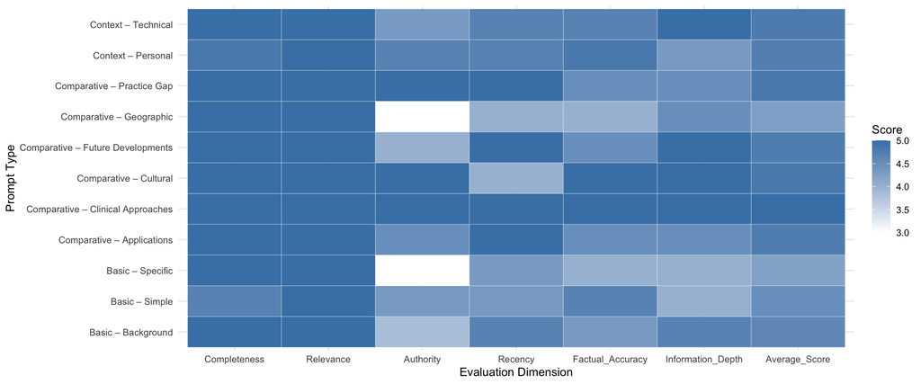

### 3.3 Bar Chart of Overall Performance

The bar chart ranks prompt types based on their overall average score. By sorting from lowest to highest and displaying results horizontally, the chart clearly reveals which prompt styles are most effective overall. It complements the heatmap by offering a more direct comparison of general effectiveness across prompt categories.

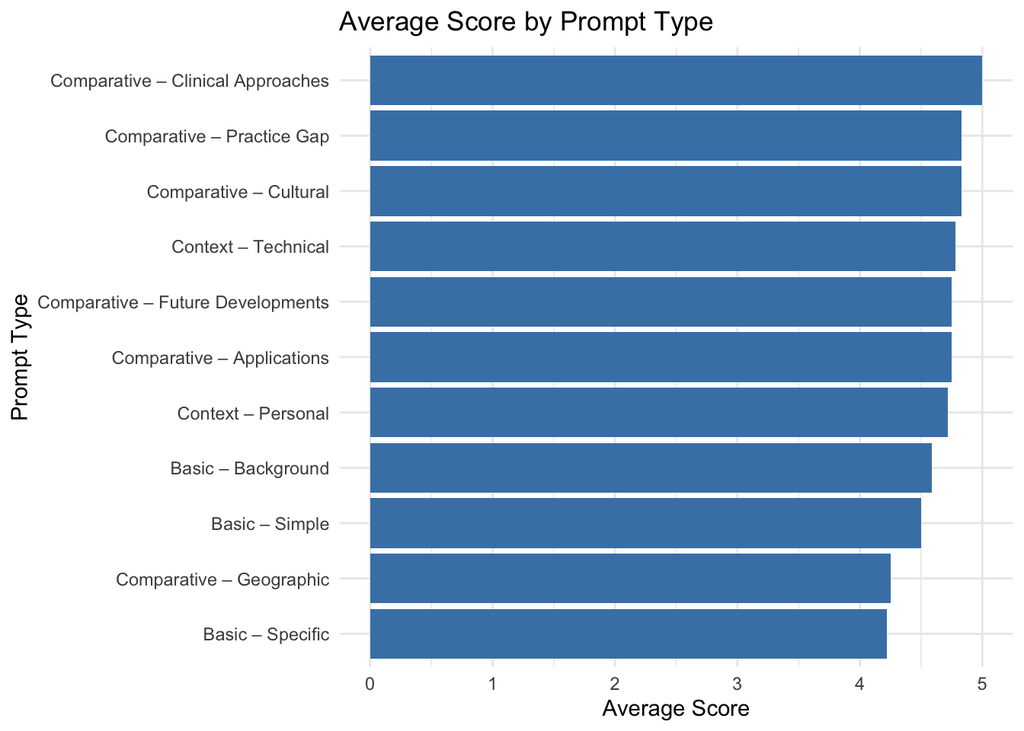

Together, the table and charts form a cohesive analytical pipeline: the table provides quantitative structure, the heatmap reveals dimension-level contrasts, and the bar chart clarifies which prompt types are most effective overall. By combining multiple visual formats, I aimed to present both granular insights and big-picture takeaways in a way that would support the key findings that follow.

## 4. Key Findings

Our evaluation revealed several important patterns in how different prompt types performed across six quality dimensions. These findings are based on the averaged scores shown in the summary table, heatmap, and bar chart.

### Top Performers

- **Comparative – Clinical Approaches** achieved a perfect score of **5.00** across all six dimensions, making it the highest-performing prompt type overall. It demonstrated exemplary completeness, authority, and depth.
- Other **comparative prompt types**—including **Practice Gap**, **Cultural**, and **Applications**—consistently scored above **4.7**, showing strong results particularly in **Authority**, **Information Depth**, and **Factual Accuracy**.

### Contextual Prompts

- **Context – Technical** prompts had an average score of **4.78**, with especially high marks for **Completeness**, **Information Depth**, and **Factual Accuracy**. This suggests technical framing can prompt the model to produce detailed, expert-level responses.
- **Context – Personal** prompts also performed well (**4.72** average), particularly excelling in **Relevance** and **Factual Accuracy**, likely due to their grounding in real-world scenarios.

### Lower-Performing Prompt Types

- **Basic prompts** (Simple, Specific, Background) generally scored lower across several dimensions:
  - While **Completeness** and **Relevance** remained high (≥ 4.67), these prompt types often lacked **Authority** and **Information Depth**, leading to average scores ranging from **4.22** to **4.59**.
  - **Basic – Specific** was the lowest-performing prompt type overall (**4.22**), with particularly low **Authority** (3.00) and **Information Depth** (4.00).
- **Comparative – Geographic** underperformed relative to other comparative prompts, with a lower **Authority score (3.00)** and overall average of **4.25**. This may reflect the difficulty of retrieving consistent, high-quality international comparisons or lack of specific regional data in retrieved sources.